# FE8828 Programming Web Applications in Finance - Session 3 -

<sub>Data Manipulation and EDA/2</sub>

Dr. Yang Ye <sub>yy@runchee.com</sub>

Sep 17, 2019

# Lecture 7: Data Manipulation and EDA/2

## Joins

[figure not shown]

# `left_/right_/anti_/full_join`

Sample data:

- data_day1

  | Date | Position_id | Buy/Sell | Quantity | Risk Factor | Traded Price |
  | --- | --- | --- | --- | --- | --- |
  | 2019-11-07 | 00010001 | B | 100 | DCE_IO_1901 | 505.3 |
  | 2019-11-07 | 00010002 | B | 100 | DCE_IO_1901 | 506.8 |

- data_day2

  | Date | Position_id | Buy/Sell | Quantity | Risk Factor | Traded Price |
  | --- | --- | --- | --- | --- | --- |
  | 2019-11-07 | 00010001 | B | 100 | DCE_IO_1901 | 505.3 |
  | 2019-11-07 | 00010002 | B | 100 | DCE_IO_1901 | 506.8 |
  | 2019-11-08 | 00010003 | S | -100 | DCE_IO_1901 | 507.9 |

Positions are additive (to close a position, we won’t change the original position but to do a new reverse trade). Suppose we have two days of position data.

# `left_/right_/anti_/full_join`

In order to find the new positions. We will use:

```
# order matters, data_day2 needs to be placed first.
# anti_join is like "data_day2 - data_day1"
anti_join(data_day2, data_day1, by = "position_id")
```

In order to find old positions, we will use:

```
# inner_join ignores order
# find the common positions
inner_join(data_day2, data_day1, by = "position_id")
left_join(data_day1, data_day2, by = "position_id") # produce the same result
right_join(data_day1, data_day2, by = "position_id") # produce the same result
left_join(data_day2, data_day1, by = "position_id") # produce all items in data_day2
```

# `left_join / right_join`

They can be used to do mapping table (aka. vlookup)

Table `Product`:

```
| type_code | type_name |
| 1         | orange    |
| 2         | banana    |
```

Table `Transaction`:

```
| type_code | quantity | customer_id |
| 1         | 1        | A           |
| 2         | 3        | B           |
| 3         | 4        | C           |
| 2         | 2        | D           |
| 1         | 6        | B           |
```

Table `Customer`:

```
| customer_id | customer_phone |
| A           | +123           |
| B           | +456           |
| C           | +789           |
```

# Use `left_join` to create a full report

```
left_join(Transaction, Product, by = "type_code") %>%
left_join(Customer, by = "customer_id")

| type_code | quantity | customer_id | type_name | customer_phone |
|-----------|----------|-------------|-----------|----------------|
| 1         | 1        | A           | orange    | +123           |
| 2         | 3        | B           | banana    | +456           |
| 3         | 4        | C           | NA        | +789           |
| 2         | 2        | D           | banana    | NA             |
| 1         | 6        | B           | orange    | +456           |
```

# `full_join` and `anti_join`

- full_join(a, b): Find all combinations between table a and b.
- anti_join(a, b): Find those in a but not in b.

```r
# From something simple
df <- full_join(data_frame(a = 1:2), data_frame(a = 2:4), by = "a")
## Warning: `data_frame()` is deprecated, use `tibble()`.
## This warning is displayed once per session.
```

| a |
| --- |
| 1 |
| 2 |
| 3 |
| 4 |

```r
df <- anti_join(data_frame(a = 1:2), data_frame(a = 2:4), by = "a")
```

| a |
| --- |
| 1 |

# `full_join` and `anti_join` More

```r
# All possible combination between job and education
x <- full_join(distinct(bank, job) %>% mutate(dummy = 1),
               distinct(bank, education) %>% mutate(dummy = 1),
               by = "dummy") %>%
     select(-dummy)
y <- distinct(bank, job, education)

nrow(x)
## [1] 48
nrow(y)
## [1] 48

df1 <- anti_join(x, y, by = c("job", "education"))
df2 <- anti_join(y, x, by = c("job", "education"))
```

- df1: Empty result

| job | education |
| --- | --- |

- df2: Empty result

| job | education |
| --- | --- |

# Join is a set operation

- `full_join` is `*`
- `anti_join` is `-`
- `inner_joins` is `-`, `/`
- `left_join/right_join` is either just the same, or `*`, `/`.

# `group_by` / `summarize`

`group_by` is the way leading to analyze the data at high-dimension. `group_by` is used together with `summarize`

```
group_by(df, ...) ... is the list of variables
summarize(df, new_field = some_func_can_process_bulk_data())
```

Functions can process bulk data:

- sum/mean/median/sd: basic statistics
- min(x), quantile(x, 0.25), max(x): min/max/quantile
- n()/n_distinct(): count and count distint
- ntile: a rough divide into a few groups
- first(x), last(x), nth(x, 2)
- …

# `group_by` / `summarize`: Examples

```r
# Add paramter na.rm, if there is NA among the data.
df <- data.frame(a = c(1, 3, 4, NA))
```

| a |
| --- |
| 1 |
| 3 |
| 4 |
| NA |

```r
summarise(df, total = sum(a))
```

| total |
| --- |
| NA |

```r
summarise(df, total = sum(a, na.rm = TRUE))
```

| total |
| --- |
| 8 |

```r
summarise(df, total = mean(a))
```

| total |
| --- |
| NA |

```r
summarise(df, total = mean(a, na.rm = TRUE))
```

| total |
| --- |
| 2.666667 |

# `group_by` / `summarize`: Examples

```r
# count number of people in each age group
group_by(bank, age) %>% summarise(n = n())
```

| age | n |
| --- | --- |
| 19 | 4 |
| 20 | 3 |
| 21 | 7 |
| 22 | 9 |
| 23 | 20 |
| 24 | 24 |
| … |  |

# `group_by` / `summarize`: Examples

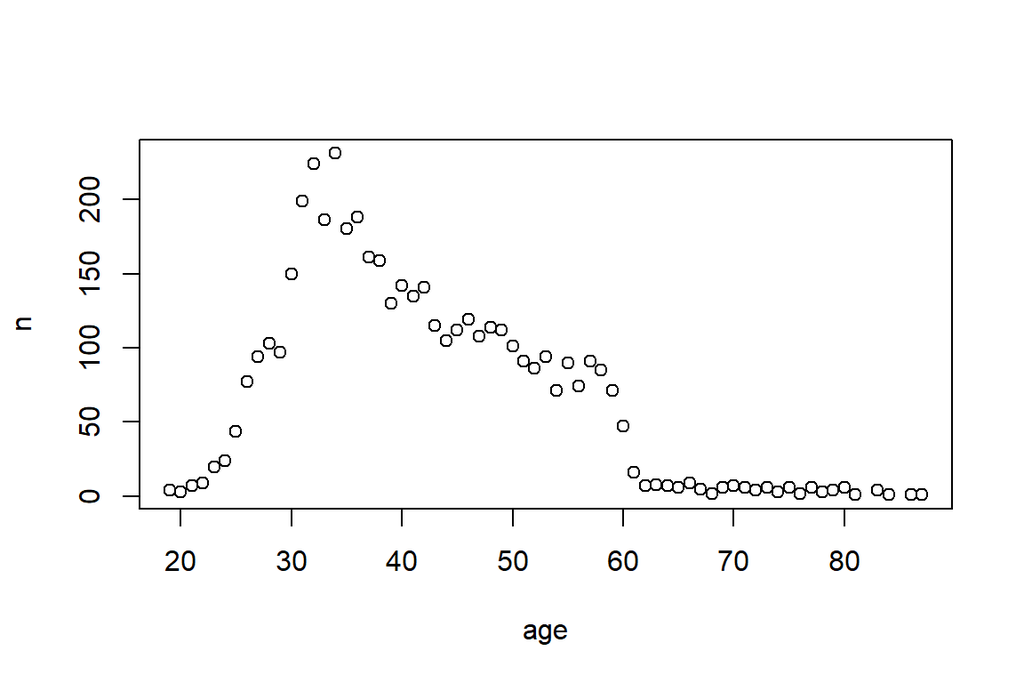

```r
group_by(bank, age) %>% summarise(n = n()) %>% plot
```

# `group_by` / `summarize`: Examples

```r
bank_age <- group_by(bank, age) %>%
         summarise(balance_mean = mean(balance),
                   count = n(),
                   default_count = sum(ifelse(default == "no", 0, 1)))
```

| age | balance_mean | count | default_count |
| --- | --- | --- | --- |
| 19 | 393.5000 | 4 | 0 |
| 20 | 661.3333 | 3 | 0 |
| 21 | 1774.2857 | 7 | 0 |
| 22 | 1455.3333 | 9 | 0 |
| 23 | 2117.9500 | 20 | 1 |
| 24 | 634.6250 | 24 | 1 |
| 25 | 1240.0682 | 44 | 1 |
| 26 | 788.5584 | 77 | 3 |
| 27 | 851.7766 | 94 | 4 |
| 28 | 1025.0971 | 103 | 1 |
| … |  |  |  |

# `group_by` / `summarize`: Examples

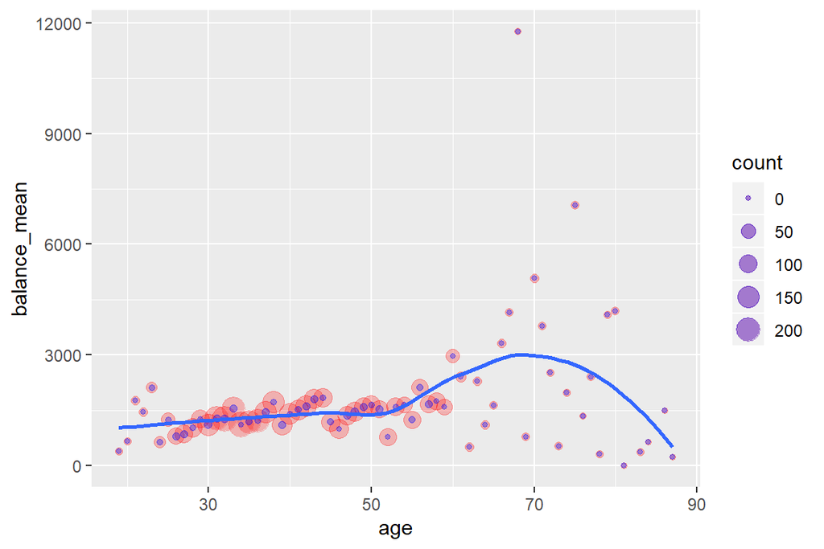

```r
# If combined with ggplot, to be learnt in next session
bank_age %>%
  ggplot(aes(x = age, y = balance_mean)) +
  geom_point(aes(size = count), alpha = 1/4, color = "red") +
  geom_point(aes(size = default_count), alpha = 1/3, color = "blue") +
  geom_smooth(se = FALSE)
## `geom_smooth()` using method = 'loess' and formula 'y ~ x'
```

# Group filter

```r
# Find the maximum and minimum balance on each age.
df <- bank %>%
  group_by(age) %>%
  filter(min_rank(balance) == 1 | min_rank(desc(balance)) == 1) %>%
  arrange(age, balance)
```

| age | job | marital | education | default | balance | housing | loan | contact | day | month | duration | campaign | pdays | previous | poutcome | y |
| --- | --- | --- | --- | --- | --- | --- | --- | --- | --- | --- | --- | --- | --- | --- | --- | --- |
| 19 | student | single | unknown | no | 0 | no | no | cellular | 11 | feb | 123 | 3 | -1 | 0 | unknown | no |
| 19 | student | single | unknown | no | 1169 | no | no | cellular | 6 | feb | 463 | 18 | -1 | 0 | unknown | no |
| 20 | student | single | secondary | no | 291 | no | no | telephone | 11 | may | 172 | 5 | 371 | 5 | failure | no |
| 20 | student | single | secondary | no | 1191 | no | no | cellular | 12 | feb | 274 | 1 | -1 | 0 | unknown | no |
| 21 | student | single | secondary | no | 6 | no | no | unknown | 9 | may | 622 | 1 | -1 | 0 | unknown | no |
| 21 | student | single | secondary | no | 6844 | no | no | cellular | 14 | aug | 126 | 3 | 127 | 7 | other | no |
| 22 | student | single | unknown | no | 47 | no | no | cellular | 3 | jul | 69 | 3 | -1 | 0 | unknown | no |
| 22 | admin. | single | secondary | no | 4111 | no | yes | cellular | 19 | aug | 65 | 1 | -1 | 0 | unknown | no |
| 23 | technician | single | secondary | no | -306 | yes | no | unknown | 4 | jun | 217 | 2 | -1 | 0 | unknown | no |
| 23 | student | single | secondary | no | 9216 | no | no | cellular | 5 | jun | 471 | 2 | -1 | 0 | unknown | no |
| … |  |  |  |  |  |  |  |  |  |  |  |  |  |  |  |  |

# Count for condition

TRUE => 1, FALSE => 0

```r
# Generate a report for balance and job
d1 <- group_by(bank, job) %>%
  summarise(`balance > 500` = sum(balance > 500))
d2 <- group_by(bank, job) %>%
  summarise(`balance <= 500` = sum(balance <= 500))
# df collects all jobs, in case some jobs are missing from either d1 or d2
# This is a typical example for collecting data.
df <- distinct(bank, job) %>% arrange(job)
df <- left_join(df, d1, by = "job")
df <- left_join(df, d2, by = "job")
df <- mutate(df, total = `balance > 500` + `balance <= 500`)
```

| job | balance > 500 | balance <= 500 | total |
| --- | --- | --- | --- |
| admin. | 226 | 252 | 478 |
| blue-collar | 423 | 523 | 946 |
| entrepreneur | 74 | 94 | 168 |
| housemaid | 42 | 70 | 112 |
| management | 521 | 448 | 969 |
| retired | 127 | 103 | 230 |
| self-employed | 89 | 94 | 183 |
| services | 154 | 263 | 417 |
| student | 41 | 43 | 84 |
| technician | 353 | 415 | 768 |
| unemployed | 63 | 65 | 128 |
| unknown | 21 | 17 | 38 |

# `group_by` and `summarise/summarize`: Further explain

- `group_by` is a like folding a paper without tearing it later.
- `summarise` tears the paper to do individual pieces.
- Therefore, `group_by` can be used with other verbs, `mutate`, `filter`, which will work within the group.
- `summarise` can be used without group_by, then it will apply to entire data as one whole group.

# `group_by`

```r
# mutate with group_by
df <- group_by(data.frame(a = 1:10), quantile = ntile(a, 2)) %>%
  mutate(b = a / sum(a))
```

| a | quantile | b |
| --- | --- | --- |
| 1 | 1 | 0.0666667 |
| 2 | 1 | 0.1333333 |
| 3 | 1 | 0.2000000 |
| 4 | 1 | 0.2666667 |
| 5 | 1 | 0.3333333 |
| 6 | 2 | 0.1500000 |
| 7 | 2 | 0.1750000 |
| 8 | 2 | 0.2000000 |
| 9 | 2 | 0.2250000 |
| 10 | 2 | 0.2500000 |

# `group_by` / 2

```r
# filter with group_by
df <- group_by(bank, age) %>% filter(balance == max(balance))
```

| age | job | marital | education | default | balance | housing | loan | contact | day | month | duration | campaign | pdays | previous | poutcome | y |
| --- | --- | --- | --- | --- | --- | --- | --- | --- | --- | --- | --- | --- | --- | --- | --- | --- |
| 22 | admin. | single | secondary | no | 4111 | no | yes | cellular | 19 | aug | 65 | 1 | -1 | 0 | unknown | no |
| 78 | housemaid | married | secondary | no | 499 | no | no | telephone | 16 | mar | 80 | 4 | -1 | 0 | unknown | no |
| 23 | student | single | secondary | no | 9216 | no | no | cellular | 5 | jun | 471 | 2 | -1 | 0 | unknown | no |
| 46 | management | married | secondary | no | 12186 | no | no | unknown | 20 | jun | 29 | 3 | -1 | 0 | unknown | no |
| 64 | retired | married | unknown | no | 2923 | no | no | cellular | 12 | mar | 120 | 1 | -1 | 0 | unknown | no |
| 77 | retired | married | tertiary | no | 7802 | no | no | telephone | 4 | may | 421 | 1 | 92 | 2 | success | yes |
| 39 | management | single | tertiary | no | 12437 | no | no | telephone | 18 | nov | 40 | 1 | -1 | 0 | unknown | no |
| 28 | student | single | secondary | no | 11555 | no | no | cellular | 8 | apr | 125 | 2 | -1 | 0 | unknown | no |
| 81 | retired | married | secondary | no | 1 | no | no | cellular | 19 | aug | 65 | 5 | -1 | 0 | unknown | no |
| 33 | housemaid | single | tertiary | no | 23663 | yes | no | cellular | 16 | apr | 199 | 2 | 146 | 2 | failure | no |
| 40 | self-employed | married | tertiary | no | 13669 | no | no | cellular | 15 | oct | 138 | 1 | 136 | 8 | other | no |
| 31 | housemaid | single | primary | no | 26965 | no | no | cellular | 21 | apr | 654 | 2 | -1 | 0 | unknown | yes |
| 30 | management | single | tertiary | no | 19358 | no | no | cellular | 19 | nov | 258 | 2 | -1 | 0 | unknown | no |
| 67 | blue-collar | married | secondary | no | 16353 | no | no | cellular | 27 | oct | 223 | 2 | -1 | 0 | unknown | no |
| 49 | retired | single | primary | no | 25824 | no | no | unknown | 17 | jun | 94 | 1 | -1 | 0 | unknown | no |
| … |  |  |  |  |  |  |  |  |  |  |  |  |  |  |  |  |

# `summarize/summarise`

```r
# summarise with group_by
df <- group_by(data.frame(a = 1:10), quantile = ntile(a, 2)) %>%
  summarise(b = sum(a))
```

| quantile | b |
| --- | --- |
| 1 | 15 |
| 2 | 40 |

```r
# summarise without a group_by. It will treat entire df as a whole.
df <- summarise(bank,
                with_housing = sum(housing == "yes") / n(),
                age_min = min(age),
                duration_mean = mean(duration))
```

| with_housing | age_min | duration_mean |
| --- | --- | --- |
| 0.5660252 | 19 | 263.9613 |

# `group_by`/`ungroup`

`ungroup()` removes group definition, restores the “ungrouped”" data frame back to entire data. Because `group_by` will leave a trace

```r
# wrong
df_wrong <- group_by(bank, age) %>%
  filter(balance == max(balance)) %>%
  summarize(balance = mean(balance)) %>%
  head(n = 3)

# correct
df_correct <- group_by(bank, age) %>%
  filter(balance == max(balance)) %>%
  ungroup %>%
  summarize(balance = mean(balance))
```

| age | balance |
| --- | --- |
| 19 | 1169 |
| 20 | 1191 |
| 21 | 6844 |

| balance |
| --- |
| 13541.21 |

# `group_by`/`ungroup`

```r
# We can't remove age
# R will prompt for "Adding missing grouping variables: `age`"
df1 <- group_by(bank, age) %>%
  filter(balance == max(balance)) %>%
  select(-age) %>% head(n = 3)
## Adding missing grouping variables: `age`

# We can remove age with ungroup
df2 <- group_by(bank, age) %>%
  filter(balance == max(balance)) %>%
  ungroup %>%
  select(-age) %>% head(n = 3)
```

| age | job | marital | education | default | balance | housing | loan | contact | day | month | duration | campaign | pdays | previous | poutcome | y |
| --- | --- | --- | --- | --- | --- | --- | --- | --- | --- | --- | --- | --- | --- | --- | --- | --- |
| 22 | admin. | single | secondary | no | 4111 | no | yes | cellular | 19 | aug | 65 | 1 | -1 | 0 | unknown | no |
| 78 | housemaid | married | secondary | no | 499 | no | no | telephone | 16 | mar | 80 | 4 | -1 | 0 | unknown | no |
| 23 | student | single | secondary | no | 9216 | no | no | cellular | 5 | jun | 471 | 2 | -1 | 0 | unknown | no |

| job | marital | education | default | balance | housing | loan | contact | day | month | duration | campaign | pdays | previous | poutcome | y |
| --- | --- | --- | --- | --- | --- | --- | --- | --- | --- | --- | --- | --- | --- | --- | --- |
| admin. | single | secondary | no | 4111 | no | yes | cellular | 19 | aug | 65 | 1 | -1 | 0 | unknown | no |
| housemaid | married | secondary | no | 499 | no | no | telephone | 16 | mar | 80 | 4 | -1 | 0 | unknown | no |
| student | single | secondary | no | 9216 | no | no | cellular | 5 | jun | 471 | 2 | -1 | 0 | unknown | no |

# `rowwise`

Sometimes, we need to use `rowwise()` which is a special `group_by` which makes every one row a group. `rowwise()` use case, it applies to complex logic that can’t be applied as a group.

```r
df <- data.frame(throw_dices = 1:10)
df <- rowwise(df) %>% mutate( mean = mean(sample(1:6, throw_dices, replace = TRUE)))
```

| throw_dices | mean |
| --- | --- |
| 1 | 4.000000 |
| 2 | 3.500000 |
| 3 | 2.666667 |
| 4 | 3.250000 |
| 5 | 3.400000 |
| 6 | 3.500000 |
| 7 | 3.000000 |
| 8 | 2.625000 |
| 9 | 4.000000 |
| 10 | 3.400000 |

# `bind_rows`

- bind_rows is the `+` operator for data frames.

```r
# add empty data frame is the same.
df1 <- bind_rows(data.frame(a = 3:4), data.frame())
```

| a |
| --- |
| 3 |
| 4 |

```r
df2 <- bind_rows(data.frame(), data.frame(a = 3:4))
```

| a |
| --- |
| 3 |
| 4 |

# `bind_rows`: Use case

I usually use bind_rows to collect results. For example,

```
new_positions <- data.frame()
closed_positions <- data.frame()

for (i in length(dates)-1) {
  old_date <- dates[i]
  new_date <- dates[i+1]

  new_data <- filter(position, date == new_date)
  old_data <- filter(position, date == old_date)

  new_positions <- bind_rows(new_positions,
                             anti_join(new_data, old_data, by = "position_id"))
}

# new_positions contains all new positions on their day 1
```

# `bind_rows`: Use case

If row order matters, bind_row can be used to re-order/splice and recombine.

```r
# Get head and tail
# Note: use { } to use the .
df <- arrange(bank, age) %>%
      { bind_rows(head(., n = 5), tail(., n = 5)) }
```

| age | job | marital | education | default | balance | housing | loan | contact | day | month | duration | campaign | pdays | previous | poutcome | y |
| --- | --- | --- | --- | --- | --- | --- | --- | --- | --- | --- | --- | --- | --- | --- | --- | --- |
| 19 | student | single | primary | no | 103 | no | no | cellular | 10 | jul | 104 | 2 | -1 | 0 | unknown | yes |
| 19 | student | single | unknown | no | 0 | no | no | cellular | 11 | feb | 123 | 3 | -1 | 0 | unknown | no |
| 19 | student | single | secondary | no | 302 | no | no | cellular | 16 | jul | 205 | 1 | -1 | 0 | unknown | yes |
| 19 | student | single | unknown | no | 1169 | no | no | cellular | 6 | feb | 463 | 18 | -1 | 0 | unknown | no |
| 20 | student | single | secondary | no | 502 | no | no | cellular | 30 | apr | 261 | 1 | -1 | 0 | unknown | yes |
| 83 | retired | divorced | primary | no | 0 | no | no | telephone | 31 | may | 664 | 1 | 77 | 3 | success | no |
| 83 | retired | divorced | primary | no | 1097 | no | no | telephone | 5 | mar | 181 | 1 | -1 | 0 | unknown | yes |
| 84 | retired | divorced | primary | no | 639 | no | no | telephone | 18 | may | 353 | 3 | -1 | 0 | unknown | yes |
| 86 | retired | married | secondary | no | 1503 | no | no | telephone | 18 | mar | 165 | 3 | 101 | 1 | other | no |
| 87 | retired | married | primary | no | 230 | no | no | cellular | 30 | oct | 144 | 1 | -1 | 0 | unknown | yes |

# `bind_rows`: Use case

```r
# summary
df1 <- summarise_if(bank, is.numeric, mean)
```

| age | balance | day | duration | campaign | pdays | previous |
| --- | --- | --- | --- | --- | --- | --- |
| 41.1701 | 1422.658 | 15.91528 | 263.9613 | 2.79363 | 39.76664 | 0.5425791 |

```r
# add summary to the records
df2<- tail(bind_rows(bank, summarise_if(bank, is.numeric, mean)), n = 1)
```

|  | age | job | marital | education | default | balance | housing | loan | contact | day | month | duration | campaign | pdays | previous | poutcome | y |
| --- | --- | --- | --- | --- | --- | --- | --- | --- | --- | --- | --- | --- | --- | --- | --- | --- | --- |
| 4522 | 41.1701 | NA | NA | NA | NA | 1422.658 | NA | NA | NA | 15.91528 | NA | 263.9613 | 2.79363 | 39.76664 | 0.5425791 | NA | NA |

# `bind_rows`: Use case

```r
# bind_rows can match column names and type.
# let's adjust the column order.
# As due-deligence, better to check the result.
# I remember earlier version of dplyr doesn't do match.
df <- tail(bind_rows(bank, summarise_if(bank, is.numeric, mean) %>%
  select(balance, day, everything())), n = 1)
```

|  | age | job | marital | education | default | balance | housing | loan | contact | day | month | duration | campaign | pdays | previous | poutcome | y |
| --- | --- | --- | --- | --- | --- | --- | --- | --- | --- | --- | --- | --- | --- | --- | --- | --- | --- |
| 4522 | 41.1701 | NA | NA | NA | NA | 1422.658 | NA | NA | NA | 15.91528 | NA | 263.9613 | 2.79363 | 39.76664 | 0.5425791 | NA | NA |

# `bind_cols`

- bind_cols is to extend the data frame in width.

Use cases

- It’s a lazyman’s `left_join` or `select`
- It copies the columns
- I usually find it useful to generate data frame for reports.

```r
dt1 <- bind_cols(select(bank, job), select(bank, education))
dt1[1:3,]
```

| job | education |
| --- | --- |
| unemployed | primary |
| services | secondary |
| management | tertiary |

# bind_cols

```r
dt2 <- bind_cols(dt1, dt1)
dt2[1:3,]
```

| job | education | job1 | education1 |
| --- | --- | --- | --- |
| unemployed | primary | unemployed | primary |
| services | secondary | services | secondary |
| management | tertiary | management | tertiary |

# bind_cols: Use cases

```r
d1 <- filter(bank, month == "sep") %>%
  summarize(duration = mean(duration)) %>%
  rename(`Duration Sep` = duration)
d2 <- filter(bank, month == "oct") %>%
  summarize(duration = mean(duration)) %>%
  rename(`Duration Oct` = duration)
d3 <- filter(bank, month == "nov") %>%
  summarize(duration = mean(duration)) %>%
  rename(`Duration Nov` = duration)

df <- bind_cols(d1, d2, d3)
```

| Duration Sep | Duration Oct | Duration Nov |
| --- | --- | --- |
| 215.7308 | 272.8 | 272.0668 |

# Exercise

1. How to know the row number of the wrong date

```r
df <- data.frame(dt = c("2019-10-01", "2019-31-12", "2019-03-17", "2019-02-29", "2019-09-30"))
```

[output not shown]

Output:

```
## Wrong dates on rows: 2, 4
```

# Exercise

2. How to get sub-total and total on mean of age and balance, group by job and education?

# Exercise

3. To evaluate a portfolio of options for its total value.

```r
GBSOption(TypeFlag = "p", S = 3500, X = 3765,
          Time = 1/12, r = 0, b = 0, sigma = 0.3)@price
## [1] 300.0049
df <- data.frame(type = sample(c("c", "p"), 100, replace = TRUE),
                 strike = round(runif(100) * 100, 0),
                 underlying = round(runif(100) * 100, 0),
                 Time = 1,
                 r = 0.01,
                 b = 0,
                 sigma = 0.3)
```

# tidyr: `gather`/`spread`

Wide format <=> Long format

- Wide format is more familiar to us. Column name is the data attribute.
- Long format is what we reformat the data that common attributes are gathered together as a single variable.
- Reference: Tidy data https://en.wikipedia.org/wiki/Tidy_data

# Wide v.s. Long

Wide format

```r
wfmt <- data_frame(date = seq(from = as.Date("2019-01-01"), by = "day", length.out = 5),
                   Copper_qty = round(runif(5) * 1000, 0),
                   Gold_qty = round(runif(5) * 1000, 0),
                   Silver_qty = round(runif(5) * 1000, 0))
## Warning: `data_frame()` is deprecated, use `tibble()`.
## This warning is displayed once per session.
```

[output not shown]

# Wide v.s. Long

Long format

```r
library(tidyr)
df <- gather(wfmt, key, value, -date)
```

[output not shown]

# `spread/gather` convert for Wide format <=> Long format

```
# Original help
gather(data, key, value, ...)
# My annotated version
gather(data,
       new_key_col_name,
       new_value_col_name,
       -columns_to_be_included_in_the_left)
```

… is where you want to make as independent columns. You need to specify all columns that should be `gather`ed (or before `gather`, remove all columns that should *not* be `gather`ed).

# `gather` example with *Bank* dataset

```r
wfmt <- group_by(bank, job) %>% summarize(yy = sum(ifelse(default == "yes", 1, 0)), nn = sum(ifelse(default == "no", 1, 0)))
df <- gather(wfmt, default, value, -job) %>% arrange(job, default)
```

| job | yy | nn |
| --- | --- | --- |
| admin. | 6 | 472 |
| blue-collar | 14 | 932 |
| entrepreneur | 7 | 161 |
| housemaid | 2 | 110 |
| management | 14 | 955 |
| retired | 3 | 227 |
| self-employed | 4 | 179 |
| … |  |  |

| job | default | value |
| --- | --- | --- |
| admin. | nn | 472 |
| admin. | yy | 6 |
| blue-collar | nn | 932 |
| blue-collar | yy | 14 |
| entrepreneur | nn | 161 |
| entrepreneur | yy | 7 |
| housemaid | nn | 110 |
| … |  |  |

# `spread`

```
# Original help
spread(data, key, value)
# My annotated version
spread(data, colname_to_be_header, value_to_be_filled_under_header)
```

# `spread` example with *Bank* dataset

```r
lfmt <- group_by(bank, job, default) %>% summarize(nn = n())
df <- spread(lfmt, default, nn)
# How to take care of converting NA to zero?
```

| job | default | nn |
| --- | --- | --- |
| admin. | no | 472 |
| admin. | yes | 6 |
| blue-collar | no | 932 |
| blue-collar | yes | 14 |
| entrepreneur | no | 161 |
| entrepreneur | yes | 7 |
| housemaid | no | 110 |
| … |  |  |

| job | no | yes |
| --- | --- | --- |
| admin. | 472 | 6 |
| blue-collar | 932 | 14 |
| entrepreneur | 161 | 7 |
| housemaid | 110 | 2 |
| management | 955 | 14 |
| retired | 227 | 3 |
| self-employed | 179 | 4 |
| … |  |  |

# Combine different columns’ Quantity

| date | Copper_qty | Gold_qty | Silver_qty |
| --- | --- | --- | --- |
| 2018-01-01 | 211 | 9 | 145 |
| 2018-01-02 | 225 | 408 | 682 |
| 2018-01-03 | 764 | 854 | 685 |
| 2018-01-04 | 911 | 887 | 688 |
| 2018-01-05 | 208 | 997 | 623 |
| … |  |  |  |

```r
df <- wfmt %>%
      gather(key, value, -date) %>%
      group_by(date) %>%
      summarize(value1 = sum(value)) %>%
      rename(value = value1) %>%
      mutate(key = "Total") %>%
      spread(key = key, value = value) %>%
      inner_join(wfmt, ., by = "date")
```

| date | Copper_qty | Gold_qty | Silver_qty | Total |
| --- | --- | --- | --- | --- |
| 2018-01-01 | 211 | 9 | 145 | 365 |
| 2018-01-02 | 225 | 408 | 682 | 1315 |
| 2018-01-03 | 764 | 854 | 685 | 2303 |
| 2018-01-04 | 911 | 887 | 688 | 2486 |
| 2018-01-05 | 208 | 997 | 623 | 1828 |

```r
# although this works...
# It takes "Hard coding" of column names "Copper_qty Gold_qty Silver_qty".
df <- wfmt %>% mutate(total = Copper_qty + Gold_qty + Silver_qty)
```

| date | Copper_qty | Gold_qty | Silver_qty | total |
| --- | --- | --- | --- | --- |
| 2018-01-01 | 211 | 9 | 145 | 365 |
| 2018-01-02 | 225 | 408 | 682 | 1315 |
| 2018-01-03 | 764 | 854 | 685 | 2303 |
| 2018-01-04 | 911 | 887 | 688 | 2486 |
| 2018-01-05 | 208 | 997 | 623 | 1828 |

# `separate/unite`

```
separate(data, col, into, sep = "[^[:alnum:]]+", remove = TRUE,
  convert = FALSE, extra = "warn", fill = "warn", ...)

#> # A tibble: 6 × 3
#>       country  year              rate
#> *       <chr> <int>             <chr>
#> 1 Afghanistan  1999      745/19987071
#> 2 Afghanistan  2000     2666/20595360
#> 3      Brazil  1999   37737/172006362
#> 4      Brazil  2000   80488/174504898
#> 5       China  1999 212258/1272915272
#> 6       China  2000 213766/1280428583

separate(df, rate, into = c("cases", "population"))
separate(df, rate, into = c("cases", "population"), convert = TRUE)

unite(df, century, year) # default sep is "_"
unite(df, century, year, sep = "") # seamless unite
```

# Rules of Thumb for use list of data frame

- Use list to store app data, i.e. configuration. `conf <- list(use_calendar_days = TRUE, do_fx_conversion = FALSE, year_convention = 252)`
- User data frame to store repeating data of similar structure.
- Every data frame is better to have a id column, like **item_id**. It can be number or character. Make it unique. If **item_id** is a number, when insert new record to the data frame, we need to increment it somewhere. So, use a variable to keep it somewhere, or use `max(item_id) + 1` (It will do calculation for all ids. Performance still good with small data set)
- Delete is not good for enterprise. We need to leave an audit trail. And we can prevent from wrong operation. Add a column name with a common name, e.g. SYS_DEL. Its default value is FALSE, when you want to delete it, set it to TRUE. When extracting data, use `filter(df1, !SYS_DEL)`. The advanced version involves the user and datetime, i.e. SYS_DEL_USER, SYS_DEL_DATETIME.

  ```
  | position_id | call_put | amount | strike | SYS_DEL |
  | X123        |          |        |        |
  ```

# CRUD in dplyr

Create:

- add new rows. bind_rows()

Read:

- You have known enough: filter/select/joins/… to get what you need.

Update:

- Use either data frame way or mutate.

```
# get all row numbers for students
# . refers to the output of the pipe %>%. .$nnn => df$nnn
row_nums <- mutate(bank, nnn = 1:n()) %>%
            filter(job == "student" & age < 22) %>%
            select(nnn) %>%
            .$nnn

bank1 <- bank
bank1[row_nums, "taxable"] <- "no"
bank1[setdiff(1:nrow(bank), row_nums), "taxable"] <- "yes"

# use dplyr
bank1 <- mutate(bank, taxable = ifelse(job == "student" & age < 22, "no", "yes"))
distinct(bank1, taxable)
```

Delete:

- Use filter to exclude the row(s).
- (Advanced version) Create a column `SYS_DEL` of logic type, described in detail in previous slide.

# Assignment

1. Exploratory Data Work on the bank dataset. Find 10 findings from data. Use R Markdown.

````
---
title: "FE8828 Assignment for Exploratory Data Analysis"
author: "Yang Ye <sub> <Email:yy@runchee.com> </sub>"
date: "Sep 2019"
output: html_document
---

```{r setup, include=FALSE}
library(tidyverse)
library(lubridate)
library(bizdays)
# Use echo = TRUE for assignment is an exception, so code is visible.
knitr::opts_chunk$set(echo = TRUE, fig.align="center", collapse = TRUE, cache = TRUE)
bank <- read.csv("https://goo.gl/PBQnBt", sep = ";")
```

# Finding #1
This data contains `r nrow(data)` rows.

# Finding #2
```{r}
# Find the big age group
bank %>%
  group_by(age_group = (age %/% 10) * 10) %>%
  summarise(count = n()) %>%
  arrange(age_group) -> res

res

plot(res$age_group, res$count)
```

# Discover insights of data frame: bank
- Employment
- Social attributes.
- Count for sub-total / total, plot graph
````

# Assignment

2. Book option trades

1.1 Copy the options data from https://www.nasdaq.com/symbol/goog/option-chain?dateindex=1

```
Gather data for "Dec 20, 2019" and store into following data frame format.

    | Expiry Date | Strike | Open Interest | Underlying | Call/Put | Bid | Ask
```

1.2 Count the total valuation of 1) call alone, 2) put alone, 3) call and put. `Open Interest * (Bid + Ask) / 2`

1.3 Find those in the money and get their total `Open Interest`.

1.4. Plot the volatility curve, strike v.s. vol. For strike < current price, use puts’ price; for strike > current price, use calls’ price.

```r
# GBSVolatility(price, TypeFlag, S, X, Time, r, b, tol, maxiter)
# Use Price to back-out implied volatility. Assume r = 0.03
# Example:

GBSVolatility(867.30, "c", 1135.67, 240,
              as.numeric((as.Date("2019-12-20") - as.Date("2019-09-16")))/365, r = 0.03, b = 0)
## [1] 6.86679e-19
GBSVolatility(256.50, "c", 1135.67, 880.00,
              as.numeric((as.Date("2019-12-20") - as.Date("2019-09-16")))/365, r = 0.03, b = 0)
## [1] 0.2962245
GBSVolatility(53.62, "c", 1135.67, 1120.00,
              as.numeric((as.Date("2019-12-20") - as.Date("2019-09-16")))/365, r = 0.03, b = 0)
## [1] 0.1995225
```